# GDP Components

2020-09-12

The main components of gross domestic product, GDP are personal consumption (C), business investment (I), government spending (G) and net exports (exports - imports). You can read more about GDP and the different approaches in calculating at the [Wikipedia GDP page](https://en.wikipedia.org/wiki/Gross_domestic_product).

The GDP data we will look at is from the [United Nations’ National Accounts Main Aggregates Database](https://unstats.un.org/unsd/snaama/Downloads), which contains estimates of total GDP and its components for all countries from 1970 to today. We will look at how GDP and its components have changed over time, and compare different countries and how much each component contributes to that country’s GDP.

First let’s have a look at the Excel file to see how it is structured and organised. I have used the glimpse function to view the column names and data types.

```r
UN_GDP_data  <-  read_excel(here::here("data", "Download-GDPconstant-USD-countries.xls"), # Excel filename
                sheet="Download-GDPconstant-USD-countr", # Sheet name
                skip=2) # Number of rows to skip

 glimpse(UN_GDP_data)
```

```
## Rows: 3,685
## Columns: 51
## $ CountryID     <dbl> 4, 4, 4, 4, 4, 4, 4, 4, 4, 4, 4, 4, 4, 4, 4, 4, 8, 8, 8…
## $ Country       <chr> "Afghanistan", "Afghanistan", "Afghanistan", "Afghanist…
## $ IndicatorName <chr> "Final consumption expenditure", "Household consumption…
## $ `1970`        <dbl> 5.56e+09, 5.07e+09, 3.72e+08, 9.85e+08, 9.85e+08, 1.12e…
## $ `1971`        <dbl> 5.33e+09, 4.84e+09, 3.82e+08, 1.05e+09, 1.05e+09, 1.45e…
## $ `1972`        <dbl> 5.20e+09, 4.70e+09, 4.02e+08, 9.19e+08, 9.19e+08, 1.73e…
## $ `1973`        <dbl> 5.75e+09, 5.21e+09, 4.21e+08, 9.19e+08, 9.19e+08, 2.18e…
## $ `1974`        <dbl> 6.15e+09, 5.59e+09, 4.31e+08, 1.18e+09, 1.18e+09, 3.00e…
## $ `1975`        <dbl> 6.32e+09, 5.65e+09, 5.98e+08, 1.37e+09, 1.37e+09, 3.16e…
## $ `1976`        <dbl> 6.37e+09, 5.68e+09, 6.27e+08, 2.03e+09, 2.03e+09, 4.17e…
## $ `1977`        <dbl> 6.90e+09, 6.15e+09, 6.76e+08, 1.92e+09, 1.92e+09, 4.31e…
## $ `1978`        <dbl> 7.09e+09, 6.30e+09, 7.25e+08, 2.22e+09, 2.22e+09, 4.57e…
## $ `1979`        <dbl> 6.92e+09, 6.15e+09, 7.08e+08, 2.07e+09, 2.07e+09, 4.89e…
```

[output cut: 38 more lines]

Observe that the data set consists of 3685 rows and 51 columns. For each country there are several indicator names and the values for these indicators over time are stored in separate columns for each year between 1970 and 2017. In order to plot the change in the components of GDP over time I will convert the dataset to long format i.e each row has data for one country at one time point.

```r
#creating a new dataframe  in long format
tidy_GDP_data  <- UN_GDP_data %>%
  pivot_longer(
               cols="1970":"2017", #pivot data in columns 1970-2017
               names_to = "year",
               values_to= "value"
               ) %>%
  mutate(year= year(as.Date(year, "%Y")), #converting the variable year to date format
         #shortening the names of the components of GDP
         IndicatorName= case_when(
           IndicatorName == "Imports of goods and services" ~ "Imports",
           IndicatorName == "Exports of goods and services" ~ "Exports",
           IndicatorName == "General government final consumption expenditure" ~ "Government expenditure",
           IndicatorName == "Household consumption expenditure (including Non-profit institutions serving households)" ~ "Household expenditure",
           IndicatorName =="Gross capital formation"~"Gross capital formation"
         ))

# Let us compare GDP components for these 3 countries
country_list <- c("United States","India", "Germany")
```

Having the data in long format is necessary because many R functions expect data to be in long rather than wide format. I will now create a plot of the change in the components of GDP over time for my home country *India* and compare it to the change in the components of GDP over time for USA and Germany.

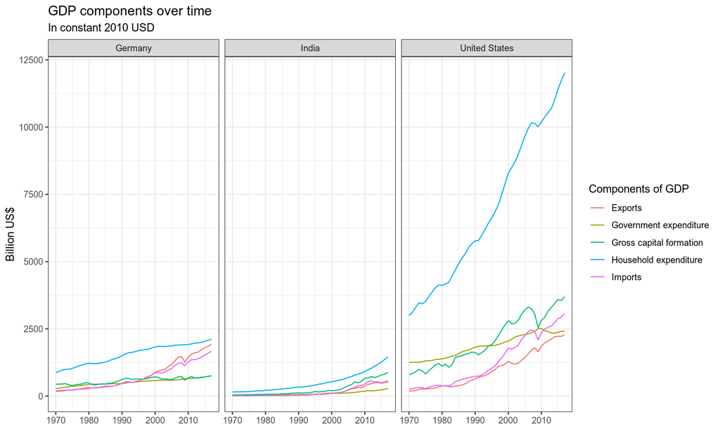

```r
gdp_time <- tidy_GDP_data %>%
  #filtering for the components of GDP and countries that we need
  filter(Country %in% country_list,
         IndicatorName %in% c("Gross capital formation",
                              "Household expenditure",
                              "Imports",
                              "Exports",
                              "Government expenditure")) %>%
  # dividing by 1e9 for easier graphical representation
  mutate(value= value/ 1e9)


ggplot(gdp_time, aes(x=year, y=value, color= IndicatorName)) +
  geom_line(aes(group=IndicatorName))+
  facet_wrap(~Country)+
  theme_bw()+
  labs(
    title = "GDP components over time",
    subtitle= "In constant 2010 USD",
    y="Billion US$",
    color= "Components of GDP"
  )+
  theme(
    axis.title.x=element_blank() #removing the label from the x-axis
  )
```

Next, I will calculate GDP for all countries in our dataset by adding up the components of GDP i.e personal consumption, business investment, government spending and net exports. To calculate net exports I first have to reshape the data to wide format and create a new column `net_exports` which will be equal to the exports minus the imports.

```r
#calculating GDP as a sum of its components
GDP_Calculated <- tidy_GDP_data %>%
  #filtering for the components of GDP
 filter(IndicatorName %in% c("Gross capital formation",
                              "Household expenditure",
                              "Imports",
                              "Exports",
                              "Government expenditure")) %>%
  pivot_wider(names_from= IndicatorName, values_from=value)


#display the first 20 rows of the new table which is in wide format
GDP_Calculated %>%
  head(20)
```

```
## # A tibble: 20 x 8
##    CountryID Country  year `Household expe… `Government exp… `Gross capital …
##        <dbl> <chr>   <dbl>            <dbl>            <dbl>            <dbl>
##  1         4 Afghan…  1970      5065091553.       372478456.       984578124.
##  2         4 Afghan…  1971      4843268618.       382280521.      1050216666.
##  3         4 Afghan…  1972      4701544472.       401884650.       918939582.
##  4         4 Afghan…  1973      5212977618.       421488779.       918939582.
##  5         4 Afghan…  1974      5588854699.       431290844.      1181493617.
##  6         4 Afghan…  1975      5650480054.       597925943.      1365281665.
##  7         4 Afghan…  1976      5681277327.       627332137.      2034794790.
##  8         4 Afghan…  1977      6149589360.       676342460.      1916645415.
##  9         4 Afghan…  1978      6303643506.       725352783.      2218582706.
## 10         4 Afghan…  1979      6151060689.       707795078.      2074341888.
## 11         4 Afghan…  1980      5951191228.       684796437.      1980288547.
## 12         4 Afghan…  1981      6056503711.       696914961.      2063015380.
## 13         4 Afghan…  1982      6185271880.       711731171.      2083612614.
## 14         4 Afghan…  1983      6493524338.       747202367.      2186661823.
## 15         4 Afghan…  1984      6607679118.       760339207.      2233917234.
## 16         4 Afghan…  1985      6627103037.       762568908.      2234857867.
## 17         4 Afghan…  1986      6825823421.       785442752.      2302700211.
## 18         4 Afghan…  1987      6124355011.       704726857.      2067297425.
## 19         4 Afghan…  1988      5618055672.       646445919.      1895406153.
## 20         4 Afghan…  1989      5221463603.       600847270.      1761869658.
## # … with 2 more variables: Exports <dbl>, Imports <dbl>
```

In the table above, one can clearly see the 5 indicators of GDP for all countries, each in a separate column. I will now calculate the net exports, pivot the data back to long format, group by year and country and finally sum all the components of GDP for each country in each year.

```r
#calculating net exports
GDP_Calculated <- GDP_Calculated %>%
  #creating a new column for net_exports
  mutate(net_exports= Exports- Imports)%>%
  #removing the columns 'Imports' and 'Exports' which are not required in the calculation of GDP
  select(-Imports, -Exports) %>%
  pivot_longer(
    cols=4:7,
    names_to = "IndicatorName",
    values_to= "value"
  ) %>%
  group_by(year, Country) %>%
  #summing the components of GDP and assigning to Gross_Domestic_Product
  summarise(Gross_Domestic_Product= sum(value))


GDP_Calculated
```

```
## # A tibble: 10,560 x 3
## # Groups:   year [48]
##     year Country             Gross_Domestic_Product
##    <dbl> <chr>                                <dbl>
##  1  1970 Afghanistan                    6350432433.
##  2  1970 Albania                        3351761022.
##  3  1970 Algeria                       46680448513.
##  4  1970 Andorra                        1051249180.
##  5  1970 Angola                        23042593319.
##  6  1970 Anguilla                         32264914.
##  7  1970 Antigua and Barbuda             262655839.
##  8  1970 Argentina                    160111327434.
##  9  1970 Armenia                                NA
## 10  1970 Aruba                           234175779.
## # … with 10,550 more rows
```

Next I will compare the GDP values that I calculated above with the actual values and compute the percentage difference between the two.

```r
#selecting indicator GDP from UN GDP data
UN_GDP <- UN_GDP_data %>%
  filter(IndicatorName=="Gross Domestic Product (GDP)") %>%
  pivot_longer(
    cols="1970":"2017",
    names_to = "year",
    values_to= "value"
  ) %>%
  rename(United_Nations_Data_GDP= "value")

GDP_Calculated <-
  GDP_Calculated %>%
  #converting year to character format to enable us to join the datasets
  mutate(year=as.character(year))

#joining the UN GDP values with the calculated GDP and computing the percentage difference
GDP_Difference<- inner_join(GDP_Calculated, UN_GDP, by=c("Country", "year")) %>%
  mutate(percentage_difference_in_GDP= (Gross_Domestic_Product-
                                          United_Nations_Data_GDP)*100/ United_Nations_Data_GDP) %>%
  #selecting only the columns that we want
  select(Country, year, percentage_difference_in_GDP)

paste("Percentage difference in GDP calculated vs GDP figure included in the dataframe:")
```

```
## [1] "Percentage difference in GDP calculated vs GDP figure included in the dataframe:"
```

```r
GDP_Difference
```

```
## # A tibble: 10,560 x 3
## # Groups:   year [48]
##    Country             year  percentage_difference_in_GDP
##    <chr>               <chr>                        <dbl>
##  1 Afghanistan         1970                       -40.8
##  2 Albania             1970                        -7.68
##  3 Algeria             1970                        17.1
##  4 Andorra             1970                         0.429
##  5 Angola              1970                        -3.83
##  6 Anguilla            1970                        -7.28
##  7 Antigua and Barbuda 1970                        -0.565
##  8 Argentina           1970                        -8.71
##  9 Armenia             1970                        NA
## 10 Aruba               1970                        -2.00
## # … with 10,550 more rows
```

```r
#using favstats from the mosaic package to display summary statistics of the percentage difference in GDP
favstats(~percentage_difference_in_GDP, data = GDP_Difference)
```

```
##    min    Q1    median   Q3 max  mean   sd    n missing
##  -54.9 -2.12 -3.08e-08 2.19 116 0.398 8.71 9574     986
```

From the table above we can see that the median % difference between calculated GDP and actual GDP is very close to 0. Next, let’s look at how the proportion of the various components of GDP has changed for India, Germany and the United States.

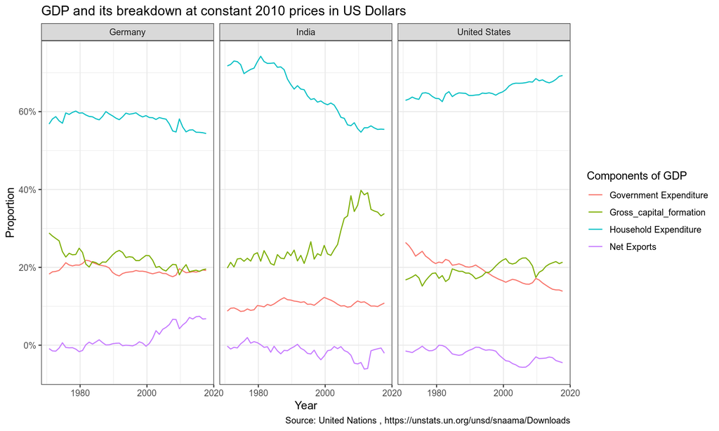

```r
trans_UN_GDP_Data <-  UN_GDP_data %>%
  #filtering for the components of GDP that we need for 3 selected countries
  filter(Country %in% c("India", "Germany", "United States"),
         IndicatorName %in% c("Gross capital formation",
                              "Household consumption expenditure (including Non-profit institutions serving households)",
                              "Imports of goods and services",
                              "Exports of goods and services",
                              "General government final consumption expenditure",
                              "Gross Domestic Product (GDP)")) %>%
  #shortening the names of the components of GDP
  mutate(
    IndicatorName= case_when(
      IndicatorName == "Imports of goods and services" ~ "Imports",
      IndicatorName == "Exports of goods and services" ~ "Exports",
      IndicatorName == "General government final consumption expenditure" ~ "Government_expenditure",
      IndicatorName == "Household consumption expenditure (including Non-profit institutions serving households)" ~ "Household_expenditure",
      IndicatorName =="Gross capital formation"~"Gross_capital_formation",
      IndicatorName =="Gross Domestic Product (GDP)"~"GDP"
    )) %>%
  pivot_longer(
    cols="1970":"2017",
    names_to = "year",
    values_to= "value"
  ) %>%
  mutate(year= as.Date(year, "%Y")) %>%
  #changing to wide format to calculate the proportion of GDP for various components
  pivot_wider(names_from = IndicatorName, values_from= "value") %>%
  mutate(
    Net_Exports= Exports- Imports,
    perc_NE= Net_Exports/ GDP,
    perc_GE= Government_expenditure/ GDP,
    perc_GCF= Gross_capital_formation/GDP,
    perc_HE= Household_expenditure/GDP
  ) %>%
  #pivoting back to long format in order to create a time series plot
  pivot_longer(cols= "perc_NE": "perc_HE", names_to= "IndicatorName", values_to= "Proportion") %>%
  mutate(
    IndicatorName= case_when(
      IndicatorName == "perc_HE" ~ "Household Expenditure",
      IndicatorName =="perc_GCF"~"Gross_capital_formation",
      IndicatorName =="perc_NE"~"Net Exports",
      IndicatorName== "perc_GE"~"Government Expenditure"
    ))

ggplot(trans_UN_GDP_Data, aes(x=year, y=Proportion, color= IndicatorName)) +
  geom_line(aes(group=IndicatorName))+
  facet_wrap(~Country)+
  theme_bw()+
  labs(
    title = "GDP and its breakdown at constant 2010 prices in US Dollars",
    y="Proportion",
    x="Year",
    color= "Components of GDP",
    caption="Source: United Nations , https://unstats.un.org/unsd/snaama/Downloads"
  )+
  theme(
    axis.title.x=element_blank(),
    legend.title = element_blank()
  )+
  scale_y_continuous(labels = scales::percent)+
  theme_bw()
```

We can also see that Germany has increased the proportion of its GDP from net exports since the early 2000s. Germany now has one of the highest trade surpluses in the world, an indicator of economic strength and competitiveness. Lastly, we can see that proportion of GDP from household expenditure has decreased sharply in India and increased in the US.